# Mental Health and Social Media Balance

## Obiettivo

L'obiettivo della seguente analisi è quello di svolgere una *EDA* su un dataset riguardante **"abitudini digitali"** e **"benessere mentale"**. [link al dataset](https://www.kaggle.com/datasets/prince7489/mental-health-and-social-media-balance-dataset)

#### Davide Cuna ~ 168363

## Struttura

1. Gli utenti in "social media detox" subiscono effetti diversi sui parametri di benessere in base all'utilizzo dello schermo rispetto a quelli non in detox?
2. In che misura l'aumento dello screen time si correla con la variazione delle metriche di benessere?
3. Ci sono differenze sostanziali nell'utilizzo dello schermo o nei parametri di benessere basati sulla piattaforma preferita?
4. Individuando una fascia più colpita dagli effetti negativi, quale range demografico ne sembra più colpito (genere ~ range di età)?

|  | age | sleep_quality | stress_level | detox_days | happiness_index |
| --- | --- | --- | --- | --- | --- |
| count | 500.000 | 500.000 | 500.000 | 500.000 | 500.000 |
| mean | 32.988 | 6.304 | 6.618 | 3.134 | 8.376 |
| std | 9.961 | 1.530 | 1.543 | 1.859 | 1.524 |
| min | 16.000 | 2.000 | 2.000 | 0.000 | 4.000 |
| 25% | 24.000 | 5.000 | 6.000 | 2.000 | 7.000 |
| 50% | 34.000 | 6.000 | 7.000 | 3.000 | 9.000 |
| 75% | 41.000 | 7.000 | 8.000 | 5.000 | 10.000 |
| max | 49.000 | 10.000 | 10.000 | 9.000 | 10.000 |

## Check Iniziale sul Dataset

Dalla descrizione del Dataset qua sopra si può notare che tutte le variabili di salute mentale sono nei range previsti osservando i minimi ed i massimi. Anche l'età è in un range sensato.

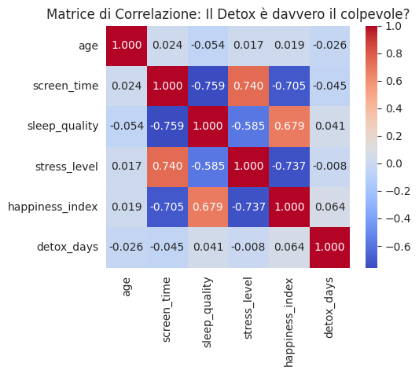

La heatmap mostra le correlazioni Pearson tra le variabili numeriche principali. L'ho riportata all'inizio per identificare relazioni lineari rilevanti ($\left| r \right| \geq 0.3$) che potrebbero richiedere approfondimenti

# EDA Univariata

La sezione che segue si concentra sulle distribuzioni delle variabili principali prese singolarmente.

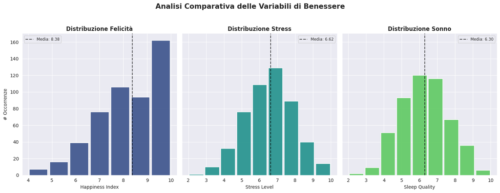

- La distribuzione dell'indice di felicità è *fortemente asimmetrica* (popolazione felice o bias nel campionamento?)
- La distribuzione dello stress e della qualità del sonno sono paragonabili ad una *gaussiana* centrata tra il 6~7

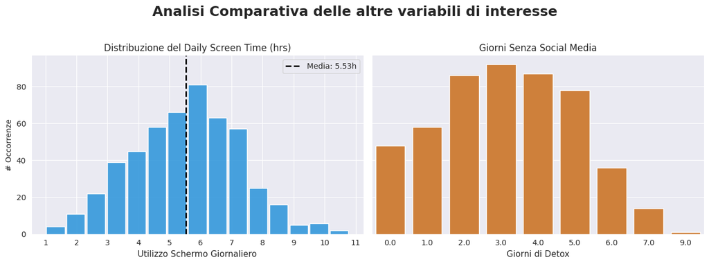

- La distribuzione dello screen time sembra simile ad una gaussiana con varianza moderata che arriva oltre le 9 ore di utilizzo
- La distribuzione dei giorni di detox è abbastanza piatta nel range 2~5 suggerendo che la maggior parte della popolazione sta attivamente provando a ridurre l'utilizzo dei social; la rapida decrescita dopo i 5 giorni mostra però la "difficoltà" nello staccarsi dai social.

## Domanda 1: Gli utenti in "social media detox" subiscono effetti diversi sui parametri di benessere in base all'utilizzo dello schermo rispetto a quelli non in detox?

### Ipotesi

A parità di screen time, gli utenti mostrano un andamento diverso delle metriche di benessere rispetto ai non detox.

### Metodo

Confronto delle metriche di benessere al variare dello screen time nei due gruppi (detox vs non detox) tramite regression plot.

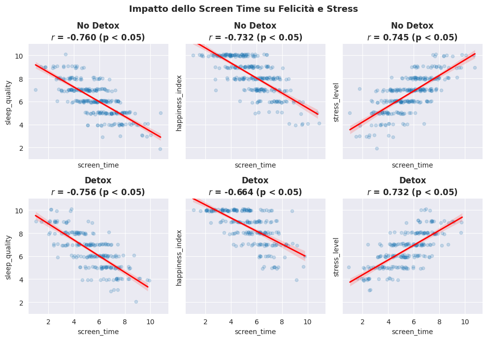

### Interpretazione

La diversa pendenza suggerisce un possibile effetto moderatore del detox sulla felicità.

## Domanda 2: In che misura l'aumento dello screen time si correla con la variazione delle metriche di benessere?

### Ipotesi

Un aumento dello screen time è associato ad un peggioramento delle metriche di benessere

### Metodo

Confronto dei violinplot suddividendo la popolazione in base all'utilizzo dello schermo (in quartili) ed esaminando la distribuzione delle metriche di benessere

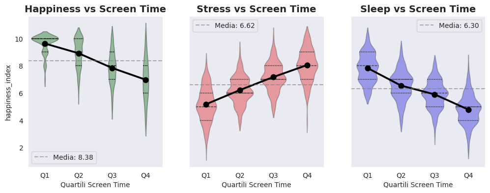

| Quartile | Range (Ore/Giorno) | Interpretazione |
| --- | --- | --- |
| **Q1 + Q2** | 1:00 - 4:20 - 5:36 h | **Trend Lineare:** l'aumento dello screen time correla direttamente con il calo del benessere. |
| **Q3** | 5:37 - 7:42 h | **Varianza in aumento:** più ci si spinge verso l'ultimo quartile, più le reazioni tra gli utenti diventano eterogenee. |
| **Q4** | 7:43 - 10:48 h | Questo indica che oltre una certa soglia l'impatto diventa soggettivo o influenzato da altre variabili. |

## Domanda 3: Ci sono differenze sostanziali nell'utilizzo dello schermo o nei parametri di benessere basati sulla piattaforma preferita?

### Metodo

Tramite analisi dei boxplot di ogni piattaforma presente nel dataset in riferimento alla qualità del sonno, al livello di stress e allo screen time giornaliero.

### Limite

L'analisi non controlla le altre variabili (come età, uso totale, motivazioni, ...), quindi le differenze non sono interpretabili in maniera certa

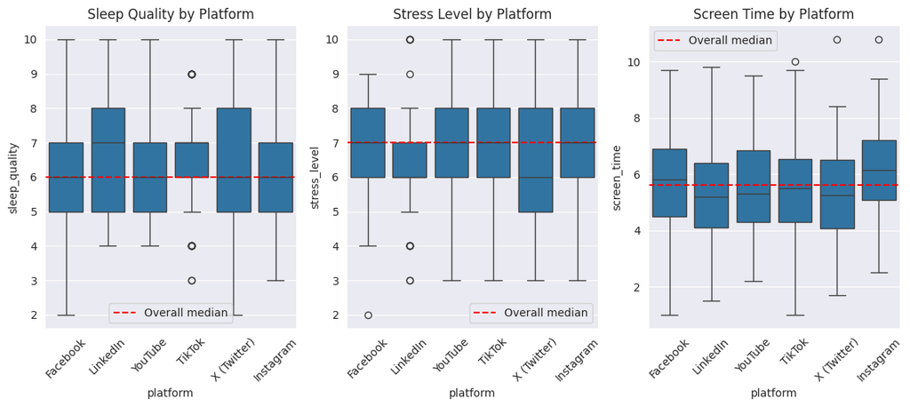

### Interpretazione

Si può notare uno screen time minore per LinkedIn e X che giustificherebbero una migliore qualità del sonno per LinkedIn ed uno Stress sotto la mediana per X.

## Domanda 4: Individuando una fascia più colpita dagli effetti negativi, quale range demografico ne sembra più colpito (genere ~ range di età)?

### Definizione di "essere colpiti"

Con questo termine si intende una maggiore sensibilità negativa delle metriche di benessere in corrispondenza ad un aumento dello screen time.

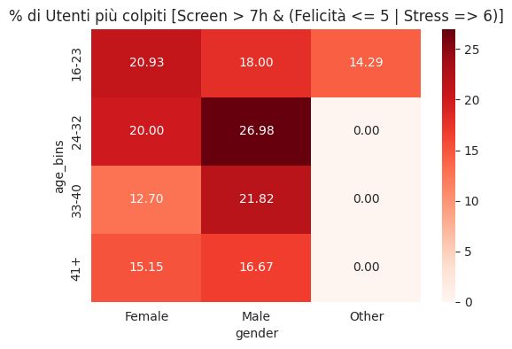

### Risultato

Il gruppo di maschi di età compresa tra i 24 e 32 anni hanno la percentuale di popolazione più colpita, mentre le femmine nel range 33-40 sono le meno colpite. Possiamo notare anche una differenza tra generi nell'evoluzione del trend, in base al genere si nota un cambiamento nel come e quanto vengono colpite le varie sezioni della popolazione.

# Conclusioni

L'analisi delle "abitudini digitali" e del "benessere mentale" condotta sul campione di 500 utenti rivela una chiara interconnessione tra l'esposizione prolungata agli schermi e il deterioramento dei parametri di benessere, confermando come l'equilibrio digitale sia un fattore critico per la salute moderna.

## Invece riguardo i singoli social media e la popolazione in generale:

1. Non ci sono piattaforme che peggiorano significativamente le condizioni apparte qualche menzione d'onore leggermente migliore delle altre. Ciò ci da un'ulteriore conferma che lo screen time è quello che conta.
2. I maschi (24~32) e le femmine (16~23) sono i frammenti della popolazione che ne risentono di più negativamente dall'utilizzo del telefono riscontrando casi di stress elevato o tristezza in corrispondenza all'elevato numero di ore passato davanti allo schermo.